# Individual Project EC349

Rowan Vinayak

2023-12-2

## Predicting Yelp Reviews

### Introduction

I chose to adopt a flexible approach to the **CRISP-DM** methodology for this assignment. It provides a structured, comprehensive and cyclical framework that supports the iterative nature of data science (DSPA, 2021). My flexible approach ensured that I constantly and quickly iterated through processes rather than working too much on part. This allowed me to build an initial model that I could then improve from. I value the CRISP-DM methodology’s emphasis on the initial *understanding* phase since this helped me focus on the specific problem at hand. Its six phases are easy to understand and encouraged me to critically think and ask questions throughout about my analysis.

#### Classification or regression problem?

Since user reviews can be either 1,2,3,4 or 5, I employed a classification approach by transforming the outcome variable **review_star** into a factor variable with 5 levels.

I utilise confusion matrices to evaluate the performance of the random forest model on the test dataset.

This report contains 4 sections:

1. Data preparation
2. Exploratory data analysis (EDA) and model selection
3. Model implementation, tuning and accuracy *(and most difficult challenge)*
4. Model evaluation

### Data preparation

After loading the datasets, I concluded that the tip dataset contained no useful information above the others and is therefore excluded. I then merged the datasets by user or business id.

#### Cleaning the dataset

To enhance data quality and completeness, I removed:

- The 39 attributes, each with at least 95,000 missing observations.
- The hours variable - the 7 days of the week each had at least 80,000 missing observations.
- Variables with high cardinality (address, postal code, latitude and longitude variables) since these could potentially cause overfitting. Geographic differences are already covered by the state variable.

I then removed any observations (54) with missing data.

Finally, I produced a smaller sample of 200,000 (for computational time), called yelp_sample.

In addition to the base variables in the yelp datasets, I explore the impact of 9 other variables on **review_star**:

1. The length of a review (in words)
2. The number of friends a user has
3. The sentiment of a review using the AFINN lexicon<sup>1</sup>
4. The emotional sentiment of a review using the NRC lexicon<sup>1</sup>
5. The month a user has been yelping since
6. The year a user has been yelping since
7. The month of a review
8. The year of a review
9. The number of checkin dates a business has (called DateCount)

<sup>1</sup>I follow the text mining process outlined by Silge and Robinson (2017, ch.2).

The NRC lexicon provides data about the emotional content in text, producing the variables positive, negative and 8 emotion variables (anger, sadness fear etc.). The sentiment scores from the AFINN lexicon are contained in the variable sentiment_score.

### Exploratory data analysis (EDA) and model selection

I use EDA to analyse the relationship between certain key predictors and **review_star**, and to provide insights into which classification model is the most appropriate.

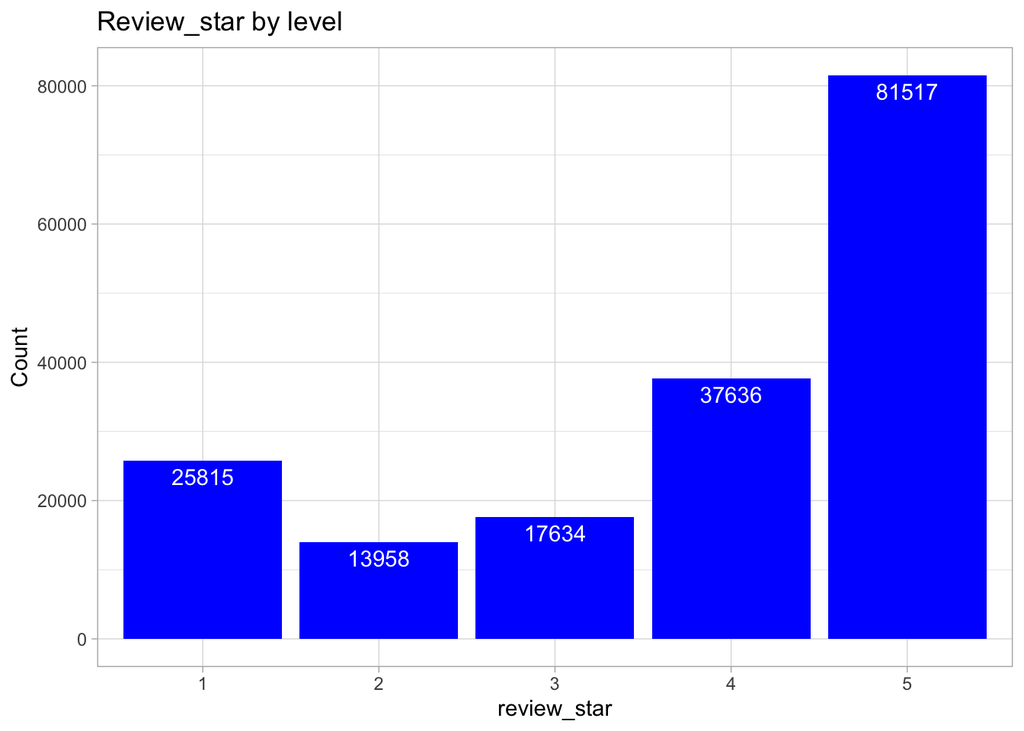

In the training dataset, **review_star** has uneven class distribution with 5 being the most common review rating. As shown below, a naive model which predicts 5 for each review would have an accuracy of 0.4617 on the test dataset.

```
         1          2          3          4          5
0.14622834 0.07905199 0.09989806 0.21314985 0.46167176
```

#### The relationship between review_star and key predictors

##### Date of review

The graph below illustrates monthly averages of **review_star** by year. The monthly fluctuations suggest some seasonality in **review_star**. For most years, the average of **review_star** dips between September and December. Therefore, the date variables seem to be relevant predictors.

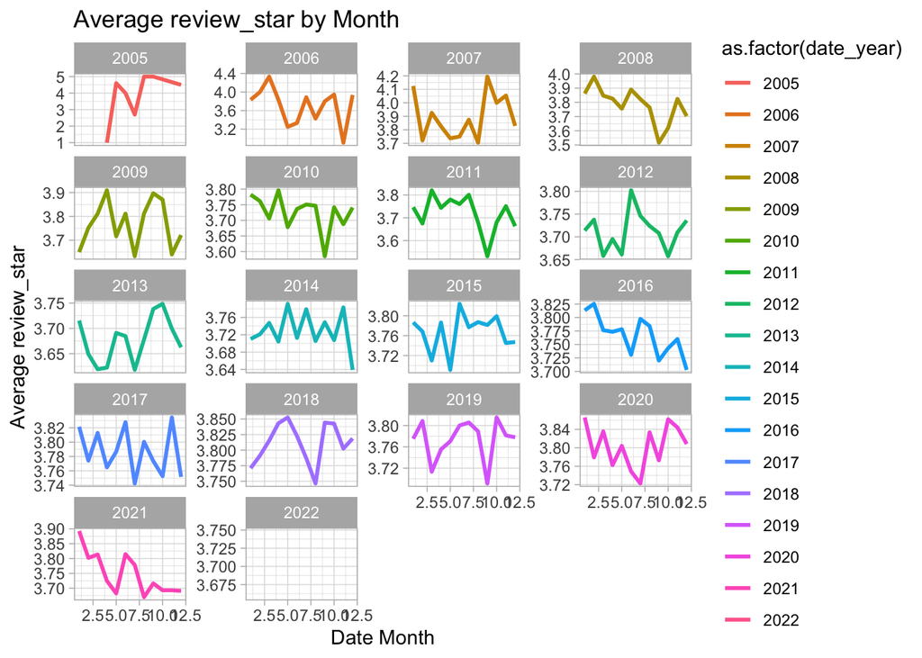

##### Sentiment score (AFINN lexicon)

The graphs below show a clear positive relationship between sentiment score and **review_star** for most observations. However, some data points with low sentiment scores have a high **review_star** and vice versa which may challenge the model. Also, the box plot illustrates that sentiment_score does not distinguish well between 4 and 5 star reviews.

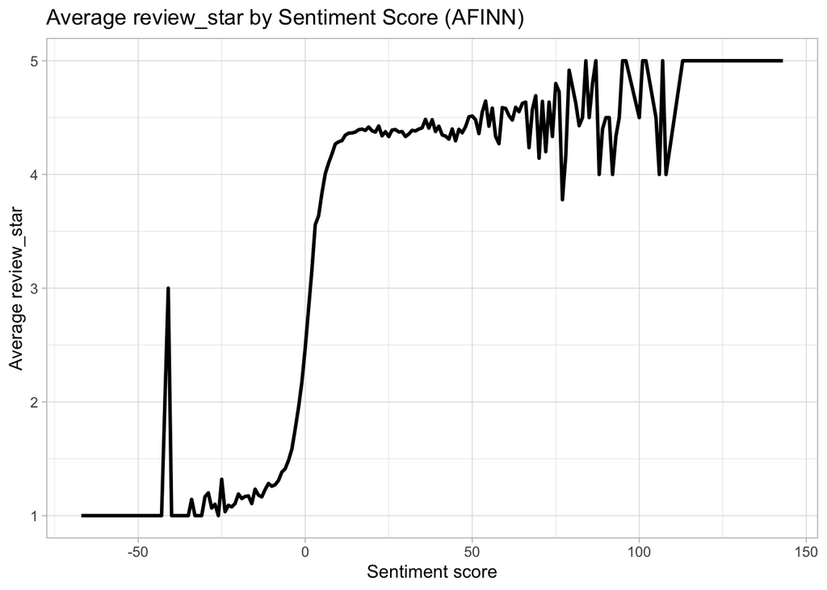

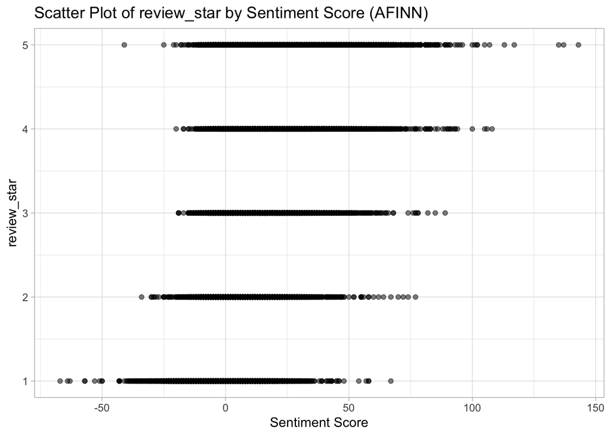

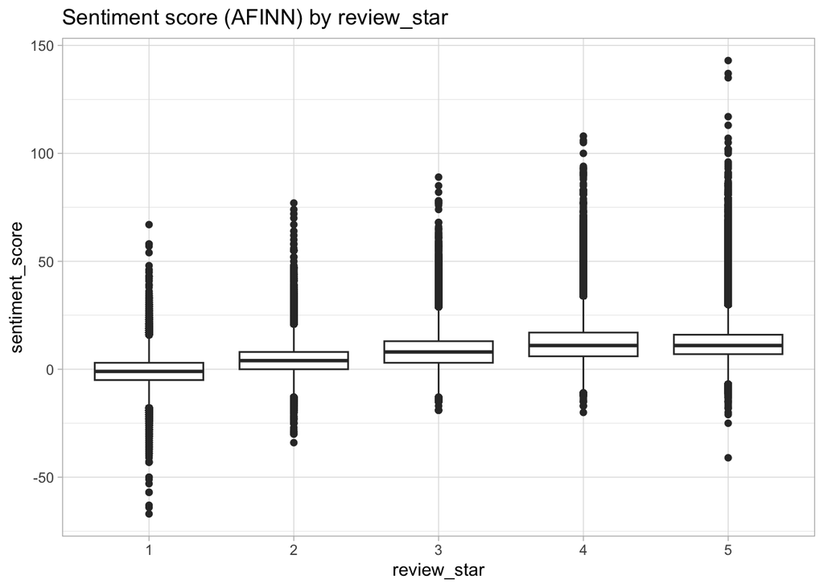

The below shows the R<sup>2</sup> from a line of best fit for each of the NRC lexicon variables and other key predictors. Many of the R<sup>2</sup>s are low, highlighting the highly non-linear relationship between **review_star** and several predictors.

```
R² for sentiment_score : 0.2069115
R² for negative : 0.1327052
R² for positive : 1.617625e-06
R² for joy : 0.00904919
R² for anger : 0.09341091
R² for trust : 0.001156775
R² for sadness : 0.0967133
R² for disgust_sentiment : 0.1438181
R² for anticipation : 0.005373931
R² for fear : 0.06604338
R² for surprise : 0.002176667
R² for average_stars_user : 0.3327123
R² for word_count : 0.04435323
R² for DateCount : 0.001255075
R² for friend_count : 0.001479097
```

The graph below shows the strong positive relationship between the average stars given by a user and **review_star**.

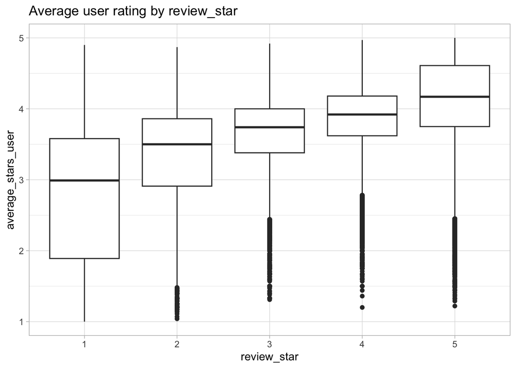

The correlation matrix below shows the correlation between each numeric or integer variable in the training dataset (review_star has been converted to numeric for this). There is a high correlation between many of the predictor variables.

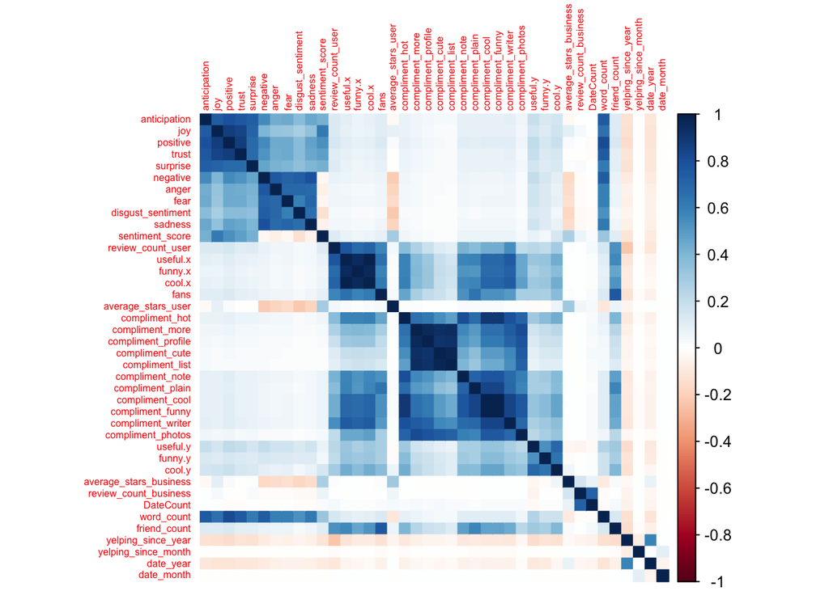

Below is an impurity-based variable importance graph (Boehmke and Greenwell, 2020, ch.11). The feature importance is determined by calculating the average overall reduction in the loss function (in our case the **Gini index**) associated with a particular feature across all trees in the model. average_stars_user and sentment_score are determined to be the two most important predictors.

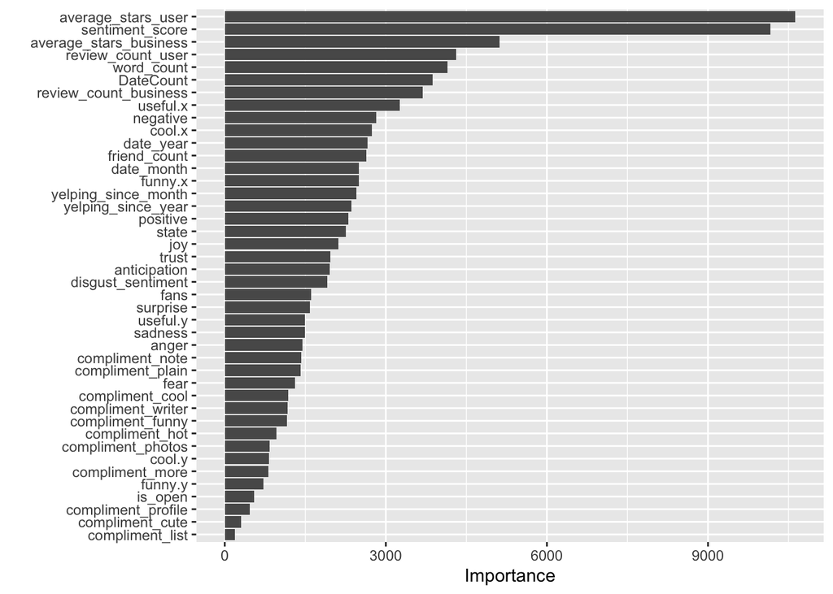

### Model implementation, tuning and accuracy *(and most difficult challenge)*

The most difficult challenge in carrying out this project was the computational burden of random forest. The **randomForest** package was slow (particularly considering the number of observations and predictors).

To overcome this, I took inspiration from Wright’s and Ziegler’s (2017) use of the **ranger** package. This package is a fast implementation of random forests for high dimensional data.

An untuned ranger with 500 trees and mtry = 6 has an accuracy of 0.6208461 on the test data:

```r
# Set seed for reproducibility
set.seed(1)
# Use the ranger package to run a random forest of review_star on all the predictors, except ones which would cause over fitting
yelp_rf <- ranger(
  review_star ~ .-user_id -business_id -friends -text -review_id - name.x -name.y -elite -yelping_since -categories -CheckInDates -city -date,
  data = train_data,
  respect.unordered.factors = "order",
  verbose = FALSE
)

# Run the model on the test data
test_predictions <- predict(yelp_rf, test_data)

# Store predictions as factor
predicted_classes <- as.factor(test_predictions$predictions)

# Confusion matrix to test accuracy of model on test data.
confusionMatrix(predicted_classes, test_data$review_star)$overall["Accuracy"]
```

```
 Accuracy
0.6208461
```

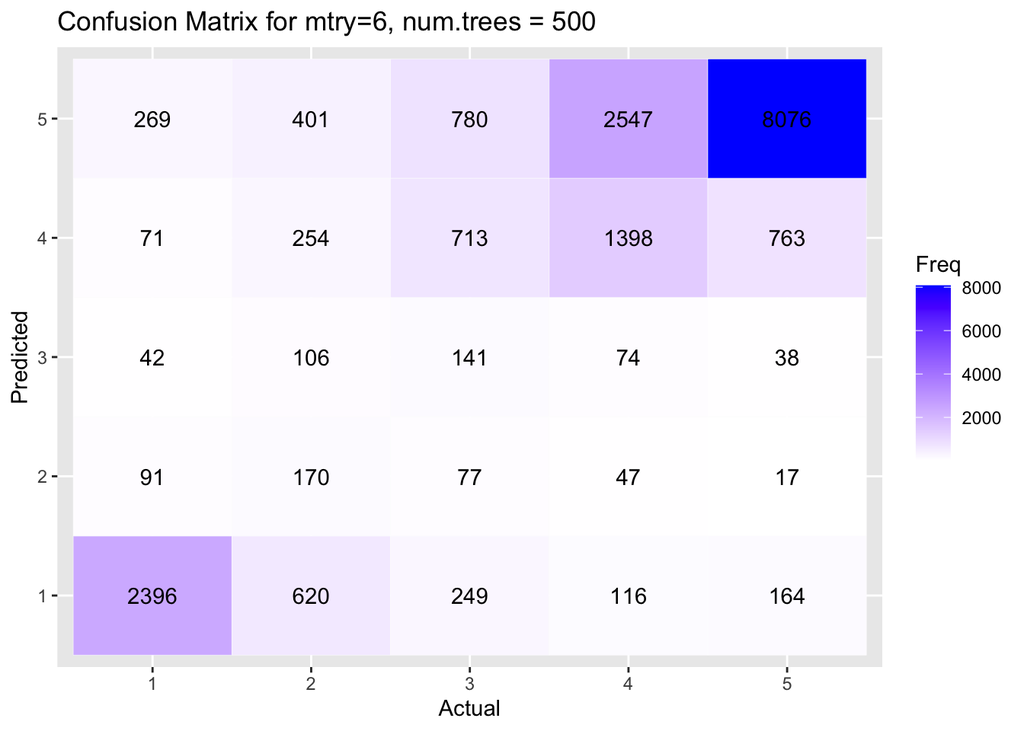

```
How often the prediction is within 1 of the actual rating: 0.875229357798165
```

#### Corpus for text analysis

A corpus is a structured set of documents for pre-processing text data (Welbers et al. 2017). The code is extensive so I give a summary of the steps I took for the corpus text analysis: I converted the text data to a corpus, cleaned the corpus (e.g. converted all words to lowercase), stemmed the corpus and then converted the corpus to a Document Term Matrix showing the frequencies of each word. After removing words than appear in less than 0.25% of all documents, I converted the matrix to a data frame for analysis and combined this with the training data. However, there were too many word variables (over a thousand) which was a burden on computational power. Therefore, I kept only the top 200 words most correlated with **review_star** in the training data. I also added these word variables to the test data.

Some word variables in the training data are moderately correlated with each other, as shown by the correlation matrix below:

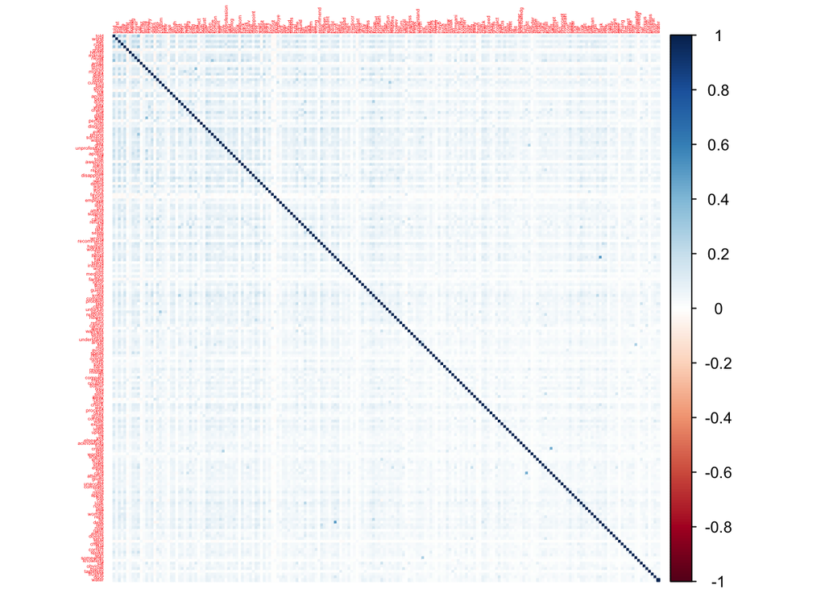

The top 10 most correlated words have correlations of:

```
       Value
1  0.5036775
2  0.5036775
3  0.4443758
4  0.4443758
5  0.3660386
6  0.3660386
7  0.3587262
8  0.3587262
9  0.3567468
10 0.3567468
```

As such, random forest is a good model (since predictors are correlated - see section 2)

An untuned ranger after corpus text analysis with num.trees = 500 and mtry = 15 has an accuracy of:

```
 Accuracy
0.6327727
```

```
How often the prediction is within 1 of the actual rating: 0.885423037716616
```

#### HyperTuning

Probst, Bischl, and Boulesteix (2018) demonstrate that among popular machine learning algorithms, random forests display the least variability in prediction accuracy when tuned. However, I tune the mtry (number of variables randomly sampled at each split of the decision tree).

For random forest classification, the default mtry is
$$\sqrt{number~of~features~(k)}$$
. However, a higher mtry increases the likelihood that decision trees choose important features in many splits (Ellis, 2022). Since we have many predictors, some with low predictive power, a higher mtry (than default) produces higher accuracy. The optimal mtry is 60 with an accuracy of 0.6456677. Additionally, increasing the number of trees from 500 had a very minimal effect on accuracy.

```
             mtry  accuracy
10.Accuracy    10 0.6291030
20.Accuracy    20 0.6355250
30.Accuracy    30 0.6388379
40.Accuracy    40 0.6430173
50.Accuracy    50 0.6429664
60.Accuracy    60 0.6456677
70.Accuracy    70 0.6450051
80.Accuracy    80 0.6437819
90.Accuracy    90 0.6435270
100.Accuracy  100 0.6436290
```

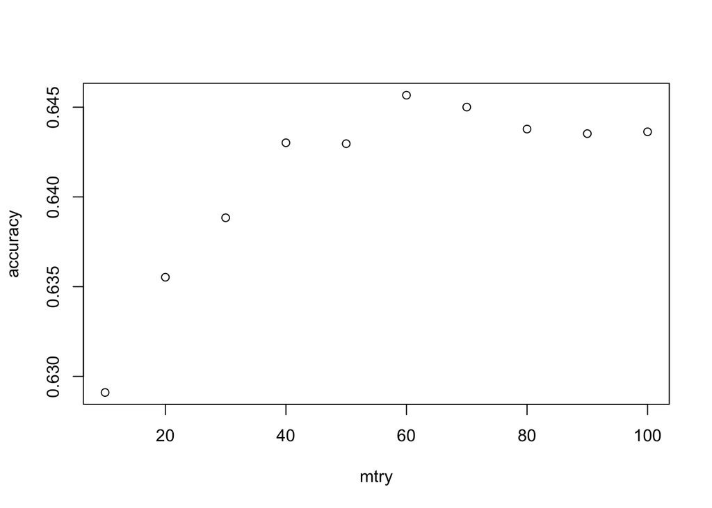

#### The final tuned model

```r
set.seed(1)
yelp_rf3 <- ranger(
  review_star ~ .-user_id -business_id -friends -text -review_id - name.x -name.y -elite -yelping_since -categories -CheckInDates -city-date,
  data = train_data_corpus,
  respect.unordered.factors = "order",
  mtry=60,
  min.node.size = 1,
  verbose = FALSE
)

test_predictions3 <- predict(yelp_rf3, test_data_corpus)

predicted_classes3 <- as.factor(test_predictions3$predictions)

confusionMatrix(predicted_classes3, test_data_corpus$review_star)$overall["Accuracy"]
```

```
 Accuracy
0.6456677
```

```
How often the prediction is within 1 of the actual rating: 0.897859327217125
```

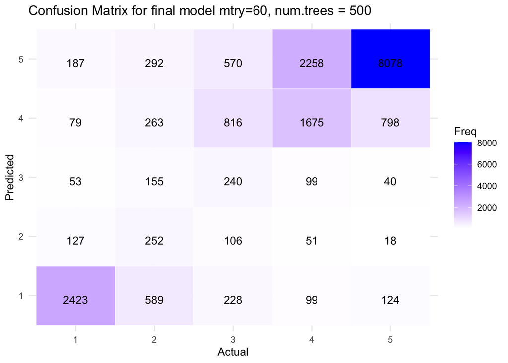

### Model evaluation

When inspecting results, I noticed that sentiment scores were sometimes highly positive when the actual review was 1 star. Further analysis suggests that sentiment scores using the AFINN and NRC lexicon fail to pick up sarcasm in text. Therefore, the model could benefit from similar approaches to Bharti et al. (2016) who use sarcasm sentiment detection in tweets. Despite this, my model’s accuracy on the test data improved overall with sentiment score analysis.

The corpus text analysis, although increasing model accuracy on the test data, could have been better implemented and refined. The word cloud below shows that words like ‘get’ and ‘one’ are common in both 1 and 5 star reviews, potentially impacting the model’s predictive power. The removal of more ‘stopwords’ could have improved this.

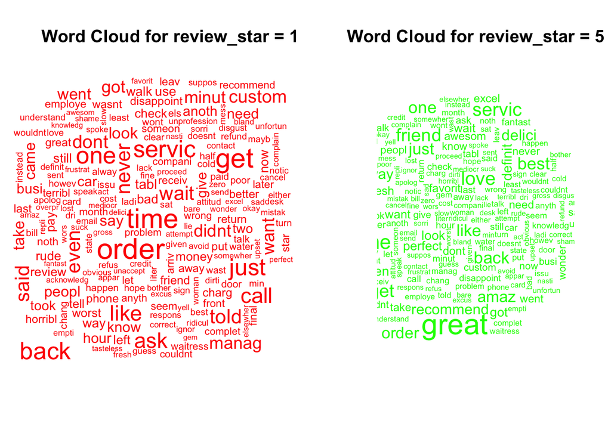

Additionally, the model could benefit from cross-validation to further prevent overfitting and produce more robust estimates.

Overall, new variables such as the year and month of review and yelping since, word count and friend count strengthened the model. The final model achieved an accuracy of 64.57% on the test data and correctly predicted within 1 star 89.79% of the time. There is potential for improved accuracy with more refined text and sentiment analysis.

### Bibliography

- Bharti, S.K., Vachha, B., Pradhan, R.K., Babu, K.S. and Jena, S.K. (2016). Sarcastic sentiment detection in tweets streamed in real time: a big data approach. Digital Communications and Networks, [online] 2(3), pp.108–121. doi:https://doi.org/10.1016/j.dcan.2016.06.002.
- Boehmke, B. and Greenwell B. (2020). Chapter 11 Random Forests | Hands-on Machine Learning with R. [online] Github.io. Available at: https://bradleyboehmke.github.io/HOML/random-forest.html
- DSPA. 2021. Evaluating CRISP-DM For Data Science. Data Science Process Alliance
- Ellis, C. (2022). Mtry in random forests. [online] Crunching the Data. Available at: https://crunchingthedata.com/mtry-in-random-forests/
- Hastie, T., Tibshirani, R. and Friedman, J. (2009). The elements of statistical learning, second edition : data mining, inference, and prediction. 2nd ed. New York: Springer
- Probst, P., Boulesteix, A.-L. and Bischl, B. (2019). Tunability: Importance of Hyperparameters of Machine Learning Algorithms. Journal of Machine Learning Research, [online] 20, pp.1–32.
- Silge, J. and Robinson, D. (2017). Text Mining with R. ‘O’Reilly Media, Inc.’
- Wright, M.N. and Ziegler, A. (2017). ranger: A Fast Implementation of Random Forests for High Dimensional Data in C++ and R. Journal of Statistical Software, 77(1). doi:https://doi.org/10.18637/jss.v077.i01